# Multiple Defaults Search Output

# mlr.classif.rpart

All plots indicate results from the learner mlr.classif.rpart.

**Current status: 100 % of results finished.**

### Caveats

- I could create the same plots for Accuracy, and F1 without any big additional effort if required.
- The current analysis contains 36 / 38 datasets for which we have data from the randomBot. I left out two datasets, because they take really long to evaluate (because they are very big).
- The general process of selecting a best configuration using nested CV seems to be decently unstable, at least in the decision trees, we sometimes get worse by selecting a bigger subset of the learned defaults. This is an interesting resarch subject in itself, but might influence our analysis.

## Average rank

The following table contains the average rank, mean auc, normalized mean auc and median of auc across n = 36 hold-out datasets. All results have been obtained using 10-fold CV splits from OpenML and 5-fold nested CV for selecting a configuration in the multiple defaults and random-search case.

```
## # A tibble: 12 x 8
## # Groups:   search.type [?]
##    search.type      n mean_rank_auc mean_auc mn_auc_norm. median_auc   cnt
##    <chr>        <dbl>         <dbl>    <dbl>        <dbl>      <dbl> <int>
##  1 design           1          3.83    0.854       0.889       0.865    36
##  2 design           2          3.08    0.869       0.934       0.893    36
##  3 design           4          3.06    0.871       0.950       0.907    36
##  4 design           6          2.67    0.873       0.967       0.905    36
##  5 design           8          2.64    0.872       0.960       0.907    36
##  6 design          10          3.42    0.872       0.953       0.906    36
##  7 package-def…     1          5.61    0.834       0.765       0.840    36
##  8 random           4         10.5     0.673       0.0370      0.641    36
##  9 random           8          9.81    0.708       0.198       0.710    36
## 10 random          16          8.78    0.743       0.357       0.770    36
## 11 random          32          7.89    0.776       0.495       0.799    36
## 12 random          64          6.5     0.806       0.646       0.813    36
## # ... with 1 more variable: cnt_na <int>
```

## Comparison to randomSearch

Boxplot of n found defaults (design) vs. package defaults and random search with design.

**Mid** Package Defaults

**Right** Randomsearch with n = 4, 8, 16, 32, 64 configurations randomly drawn from the parameter space.

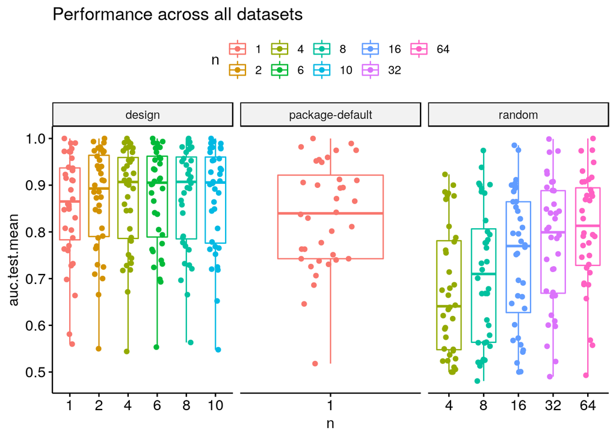

## Comparison to n-fold randomSearch

Boxplot of n (2, 4, 8) found defaults (design) vs. random search with $n \cdot 1,2,4,8$ times random search. Values $> 0$ indicate an improvement of randomsearch using multiples of n over obtained defaults.

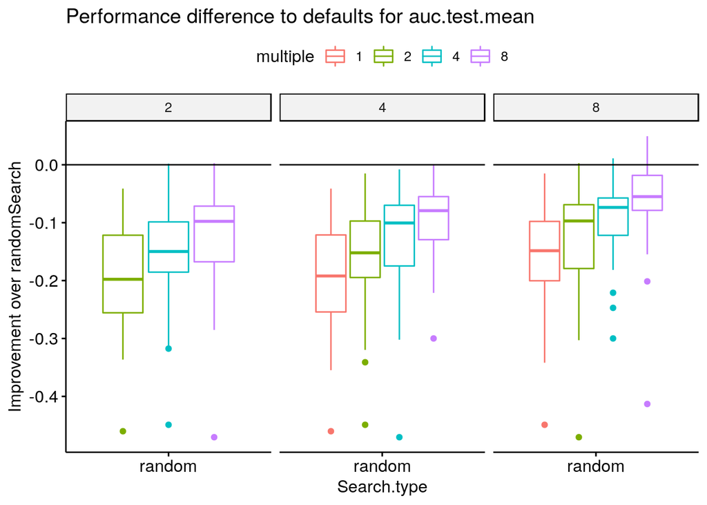

## Comparison to randomBotdata

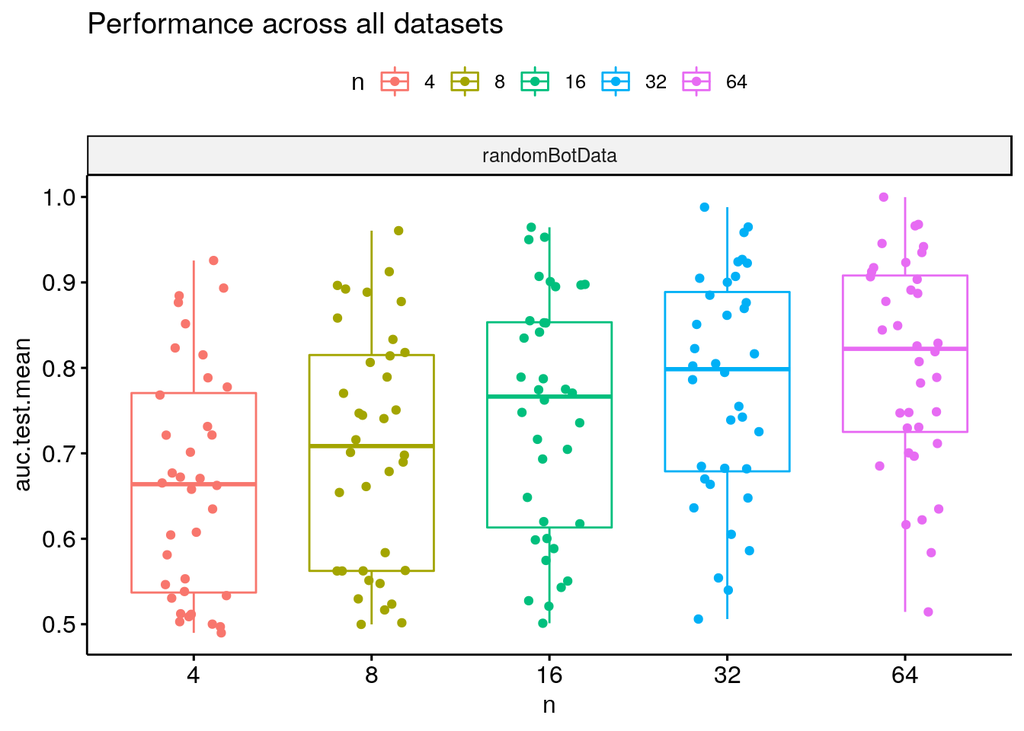

## Delta comparison to package defaults

This plot indicates the difference to package defaults measured in AUC. Values larger than 0 indicate improvement over package defaults.

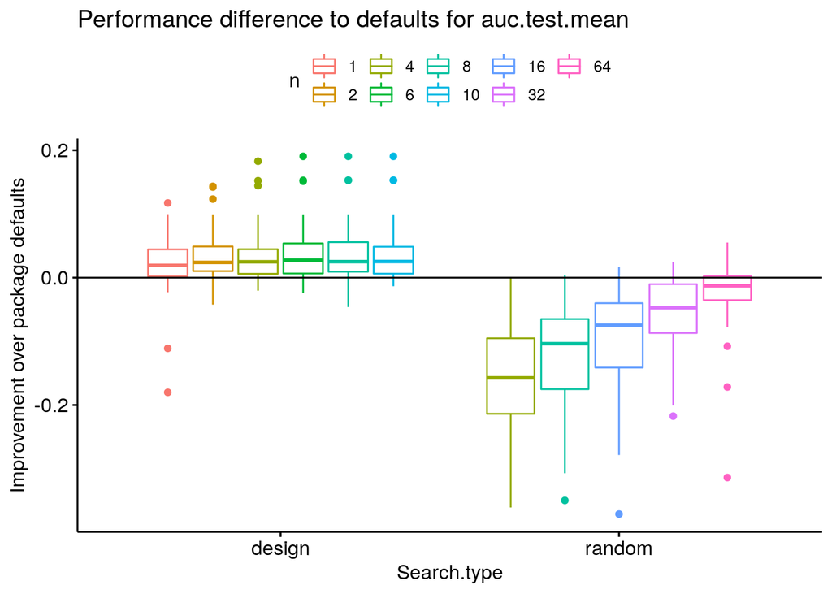

## Plotting the ranks

Plot containing the ranks of the different elements of the first table

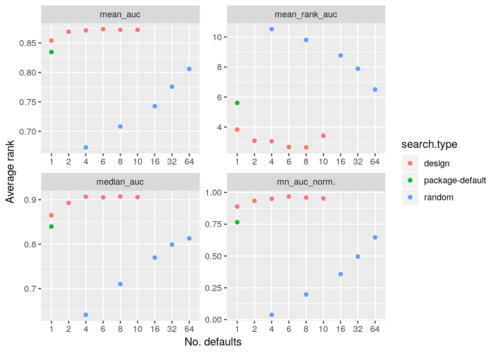

## Comparing different Aggregation functions:

**design**: Aggregate using the median

**default_mean**: Aggregate using the mean

**default_cycle**: Aggregate cycling through the quantiles (0.7, 0.3 and 0.5)

**hodges-lehmann**: Aggregate using the hodges-lehmann criterion (0.33 max() + 0.66 mean()).

If the following table does not contain differnt **search.types**, this indicates that results have not yet been computed for this learner.

*mn_auc_norm.* is short for mean_auc_normalized (normalized to [0, 1]).

```
##       search.type  n mean_rank_auc  mean_auc mn_auc_norm. median_auc cnt
## 1  defaults_cycle  1     11.444444 0.8539733    0.8730034  0.8650808  36
## 2  defaults_cycle  2      9.416667 0.8707490    0.9283727  0.8915513  36
## 3  defaults_cycle  4      8.305556 0.8737970    0.9468527  0.9070117  36
## 4  defaults_cycle  6      8.166667 0.8727425    0.9454528  0.9067461  36
## 5  defaults_cycle  8      8.416667 0.8742957    0.9464051  0.9057429  36
## 6  defaults_cycle 10      8.111111 0.8742365    0.9415879  0.9099000  36
## 7   defaults_mean  1     11.444444 0.8539733    0.8730034  0.8650808  36
## 8   defaults_mean  2      8.944444 0.8693038    0.9390346  0.9022058  36
## 9   defaults_mean  4      8.777778 0.8724444    0.9456166  0.9050242  36
## 10  defaults_mean  6      7.527778 0.8767989    0.9585183  0.9059353  36
## 11  defaults_mean  8     10.138889 0.8725304    0.9368782  0.9033618  36
## 12  defaults_mean 10      7.833333 0.8744892    0.9499384  0.9049511  36
## 13         design  1     11.444444 0.8539733    0.8730034  0.8650808  36
## 14         design  2      9.500000 0.8689322    0.9137047  0.8928822  36
```

[output cut: 35 more lines]

### Overall means for different search.types

```
## # A tibble: 4 x 5
##   search.type    mean_rank_auc mean_auc mean_auc_norm. mean_med_auc
##   <chr>                  <dbl>    <dbl>          <dbl>        <dbl>
## 1 defaults_cycle          8.98    0.870          0.930        0.898
## 2 defaults_mean           9.11    0.870          0.934        0.898
## 3 design                  9.81    0.869          0.922        0.897
## 4 hodges-lehmann          8.85    0.873          0.941        0.905
```

### Overall means for different n

```
## # A tibble: 6 x 5
##       n mean_rank_auc mean_auc mean_auc_norm. mean_med_auc
##   <dbl>         <dbl>    <dbl>          <dbl>        <dbl>
## 1     1         10.6     0.858          0.889        0.874
## 2     2          9.33    0.870          0.927        0.897
## 3     4          8.79    0.873          0.942        0.906
## 4     6          8.55    0.874          0.947        0.906
## 5     8          8.90    0.873          0.942        0.906
## 6    10          8.97    0.874          0.942        0.907
```

## TSNE Plot

Plot breaking down the parameter space to two dimensions using TSNE. The different iters refer to different Leave-One-Out Splits of the dataset.

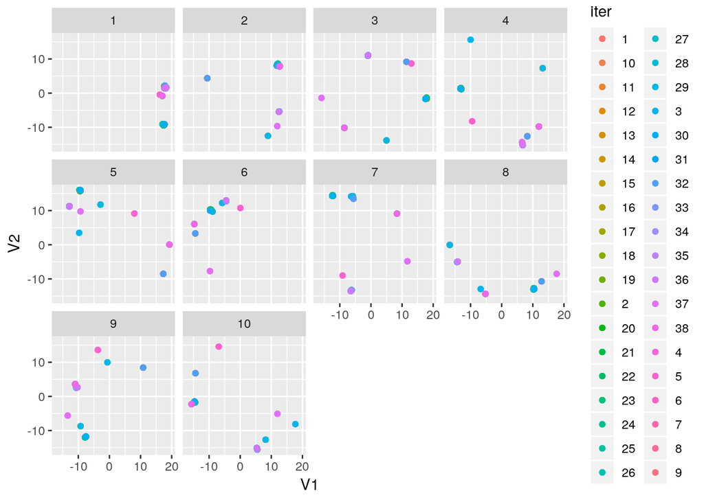